# Assignment 9

## Assignment 9 - R ML Case Study

Yagnik Bhargav , 17070122077, CS-3

### Problem Statement : : Data analysis case study for readily available data set using any one machine learning algorithm using R.

Steps to Follow :

1. Define Problem
2. Prepare Data
3. Evaluate Algorithms
4. Improve Results
5. Present Results

### 1. Load Packages

```r
library(caret)
library(caTools)
library(RColorBrewer)
library(ellipse)
```

## 2. About the dataset and loading Dataset

Dataset : Room Occupancy This dataset is a classification task where we will predict whether a person is inside a room

#### Occupancy detection of an office room from light, temperature, humidity and CO2 measurements using statistical learning models

### **2.1 Variable Identification**

- date time year-month-day hour:minute:second
- Temperature, in Celsius
- Relative Humidity, %
- Light, in Lux
- CO2, in ppm
- Humidity Ratio, Derived quantity from temperature and relative humidity, in kgwater-vapor/kg-air
- Occupancy, 0 or 1, 0 for not occupied, 1 for occupied status

So We will load the Dataset and process further

### 2.2 Load Dataset from CSV

```r
data <- read.csv("occupancy.csv")
#  data<-data[sample(nrow(data)),] Shuffle dataset
print(head(data))
```

```
              date Temperature Humidity    Light      CO2 HumidityRatio
1 02-02-2015 14:19     23.7000   26.272 585.2000 749.2000   0.004764163
2 02-02-2015 14:19     23.7180   26.290 578.4000 760.4000   0.004772661
3 02-02-2015 14:21     23.7300   26.230 572.6667 769.6667   0.004765153
4 02-02-2015 14:22     23.7225   26.125 493.7500 774.7500   0.004743773
5 02-02-2015 14:23     23.7540   26.200 488.6000 779.0000   0.004766594
6 02-02-2015 14:23     23.7600   26.260 568.6667 790.0000   0.004779332
  Occupancy
1         1
2         1
3         1
4         1
5         1
6         1
```

```r
data[data[,7]==1,][7] = "yes"
data[data[,7]==0,][7] = "no"
```

```r
data =  data[,c(2,3,4,5,6,7)]
```

### 2.3 Create a Validation dataset

```r
validation_index  <- createDataPartition(data$Occupancy,p=0.80,list=FALSE)
validation <- data[-validation_index,]
data <- data[validation_index,]
```

## 3. Summarize Dataset

### 3.1 Dimensions of Dataset

```r
dim(data)
```

1. 16448

2. 6

### 3.2 Types of Attributes

```r
sapply(data,class)
```

**Temperature**

'numeric'

**Humidity**

'numeric'

**Light**

'numeric'

**CO2**

'numeric'

**HumidityRatio**

'numeric'

**Occupancy**

'character'

### 3.3 Peak at the data

```r
head(data)
```

A data.frame: 6 × 6

|  | Temperature <dbl> | Humidity <dbl> | Light <dbl> | CO2 <dbl> | HumidityRatio <dbl> | Occupancy <chr> |
| --- | --- | --- | --- | --- | --- | --- |
| 1 | 23.7000 | 26.272 | 585.2000 | 749.2000 | 0.004764163 | yes |
| 2 | 23.7180 | 26.290 | 578.4000 | 760.4000 | 0.004772661 | yes |
| 3 | 23.7300 | 26.230 | 572.6667 | 769.6667 | 0.004765153 | yes |
| 4 | 23.7225 | 26.125 | 493.7500 | 774.7500 | 0.004743773 | yes |
| 5 | 23.7540 | 26.200 | 488.6000 | 779.0000 | 0.004766594 | yes |
| 6 | 23.7600 | 26.260 | 568.6667 | 790.0000 | 0.004779332 | yes |

```r
tail(data)
```

A data.frame: 6 × 6

|  | Temperature <dbl> | Humidity <dbl> | Light <dbl> | CO2 <dbl> | HumidityRatio <dbl> | Occupancy <chr> |
| --- | --- | --- | --- | --- | --- | --- |
| 20554 | 21.00 | 35.8600 | 433 | 771.3333 | 0.005524528 | yes |
| 20556 | 21.05 | 36.0975 | 433 | 787.2500 | 0.005578714 | yes |
| 20557 | 21.05 | 35.9950 | 433 | 789.5000 | 0.005562731 | yes |
| 20558 | 21.10 | 36.0950 | 433 | 798.5000 | 0.005595639 | yes |
| 20559 | 21.10 | 36.2600 | 433 | 820.3333 | 0.005621449 | yes |
| 20560 | 21.10 | 36.2000 | 447 | 821.0000 | 0.005612064 | yes |

### 3.4 Levels of Class

```r
levels(data$Occupany)
```

As there are Labels 0 and 1 we have Levels as None, Levels are helpful in Multiclass classification problem. We have a binary classification problem

### 3.5 Class Distribution

```r
percentage <-prop.table(table(data$Occupancy))*100
cbind(freq= table(data$Occupancy),percentage=percentage)
```

A matrix: 2 × 2 of type dbl

|  | freq | percentage |
| --- | --- | --- |
| no | 12648 | 76.89689 |
| yes | 3800 | 23.10311 |

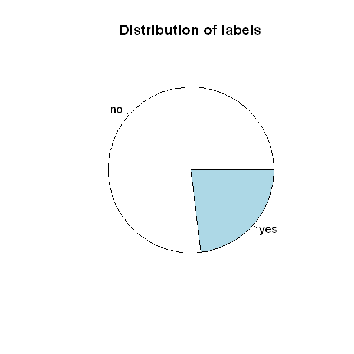

```r
options(repr.plot.width=5, repr.plot.height=5)
pie(table(data$Occupancy),main="Distribution of labels")
```

### 3.6 Statistical Summary

```r
str(data)
```

```
'data.frame':	16448 obs. of  6 variables:
 $ Temperature  : num  23.7 23.7 23.7 23.7 23.8 ...
 $ Humidity     : num  26.3 26.3 26.2 26.1 26.2 ...
 $ Light        : num  585 578 573 494 489 ...
 $ CO2          : num  749 760 770 775 779 ...
 $ HumidityRatio: num  0.00476 0.00477 0.00477 0.00474 0.00477 ...
 $ Occupancy    : chr  "yes" "yes" "yes" "yes" ...
```

```r
summary(data[,c(1,2,3,4,5)])
```

```
  Temperature       Humidity         Light             CO2
 Min.   :19.00   Min.   :16.75   Min.   :   0.0   Min.   : 414.0
 1st Qu.:20.20   1st Qu.:24.50   1st Qu.:   0.0   1st Qu.: 460.2
 Median :20.70   Median :27.29   Median :   0.0   Median : 565.0
 Mean   :20.90   Mean   :27.68   Mean   : 130.7   Mean   : 690.7
 3rd Qu.:21.50   3rd Qu.:31.29   3rd Qu.: 300.5   3rd Qu.: 803.3
 Max.   :24.41   Max.   :39.50   Max.   :1697.2   Max.   :2072.0
 HumidityRatio
 Min.   :0.002674
 1st Qu.:0.003723
 Median :0.004293
 Mean   :0.004231
 3rd Qu.:0.004834
 Max.   :0.006476
```

## 4. Visualize dataset

### 4.1 Univariate plots

```r
nocc=data[data[,6]=="no",] # Data with Occupancy as 0
nocc=nocc[,c(1,2,3,4,5)]
occ=data[data[,6]=="yes",]  # Data with Occupancy as 1
occ=occ[,c(1,2,3,4,5)]
x<- data[,c(1,2,3,4,5)]
y<- data[,6]
```

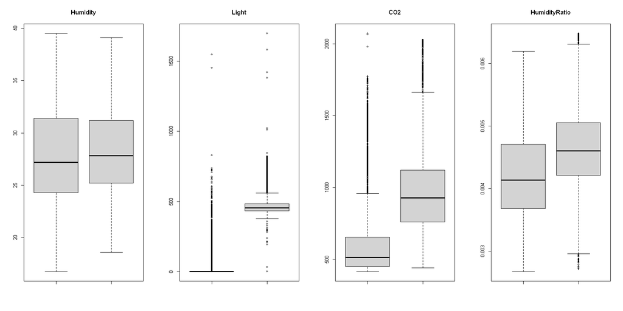

```r
options(repr.plot.width=14, repr.plot.height=7) #Change dimensions of plot
par(mfrow=c(1,4))
    for(i in seq(2,5)){
        boxplot(nocc[,i],occ[,i],main=names(data)[i])
    }
```

### 4.2 Multivariate plot

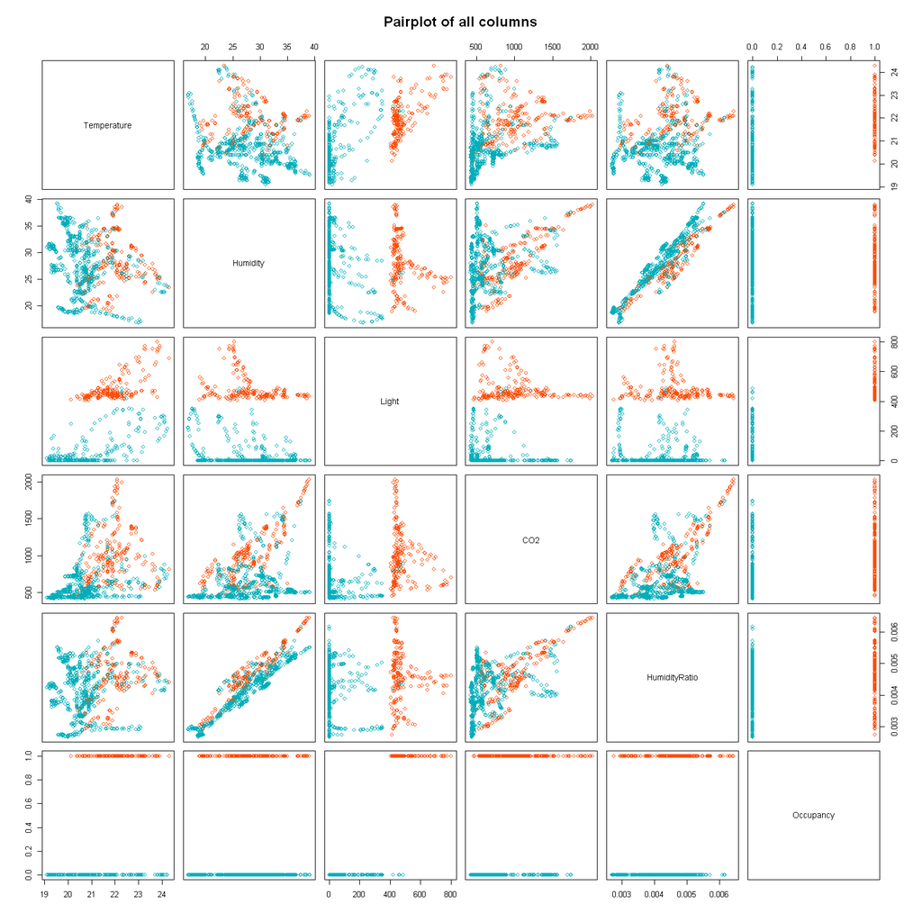

```r
options(repr.plot.width=13, repr.plot.height=13)
my_cols <- c("#00AFBB", "#FC4E07")
shuff_data<-data[sample(nrow(data)),]
shuff_data[shuff_data[,6]=="yes",][6] = 1
shuff_data[shuff_data[,6]=="no",][6] = 0
shuff_data[,6] <- as.numeric(shuff_data[,6])
pairs(head(shuff_data[,c(1,2,3,4,5,6)],1000),col=my_cols[shuff_data$Occupancy+1],main="Pairplot of all columns")
```

## 5. Evaluate Some Algorithms

1. Set-up the test harness to use 10-fold cross validation.
2. Build 5 different models to predict Occupancy in room
3. Select the best model

### 5.1 Test Harness

```r
control <- trainControl(method='cv',number=10)
metric<-"Accuracy"
```

### 5.2 Build Models

```r
# a) Linear Algorithm
set.seed(7)
fit.lda<- train(Occupancy~. , data=data,method="lda",metric=metric,trControl=control)

# b) Non-linear Algorithm

set.seed(7)
fit.cart<- train(Occupancy~. , data=data,method="rpart",metric=metric,trControl=control)

# c) KNN
set.seed(7)
fit.knn<- train(Occupancy~. , data=data,method="knn",metric=metric,trControl=control)

# d) SVM
set.seed(7)
fit.svm<- train(Occupancy~. , data=data,method="svmRadial",metric=metric,trControl=control)

# e) Random Forest
set.seed(7)
fit.rf<- train(Occupancy~. , data=data,method="rf",metric=metric,trControl=control)
```

### 5.3 Select Best Models

```r
results <- resamples(list(lda=fit.lda,cart=fit.cart,knn=fit.knn,svm=fit.svm,rf=fit.rf))
summary(results)
```

```
Call:
summary.resamples(object = results)

Models: lda, cart, knn, svm, rf
Number of resamples: 10

Accuracy
          Min.   1st Qu.    Median      Mean   3rd Qu.      Max. NA's
lda  0.9829787 0.9848024 0.9866217 0.9866243 0.9882979 0.9902736    0
cart 0.9866180 0.9892097 0.9917933 0.9913058 0.9936142 0.9951368    0
knn  0.9872340 0.9882979 0.9908787 0.9905762 0.9919453 0.9951368    0
svm  0.9860182 0.9885966 0.9902736 0.9902115 0.9923999 0.9933131    0
rf   0.9890511 0.9904255 0.9930091 0.9930083 0.9952888 0.9975669    0

Kappa
          Min.   1st Qu.    Median      Mean   3rd Qu.      Max. NA's
lda  0.9531263 0.9580540 0.9630701 0.9630602 0.9676361 0.9730206    0
cart 0.9625568 0.9698575 0.9770798 0.9757186 0.9821113 0.9863618    0
knn  0.9643633 0.9673313 0.9745194 0.9736725 0.9775095 0.9863618    0
svm  0.9613224 0.9683710 0.9729991 0.9728243 0.9788167 0.9813672    0
rf   0.9692521 0.9732491 0.9804225 0.9804139 0.9868126 0.9931546    0
```

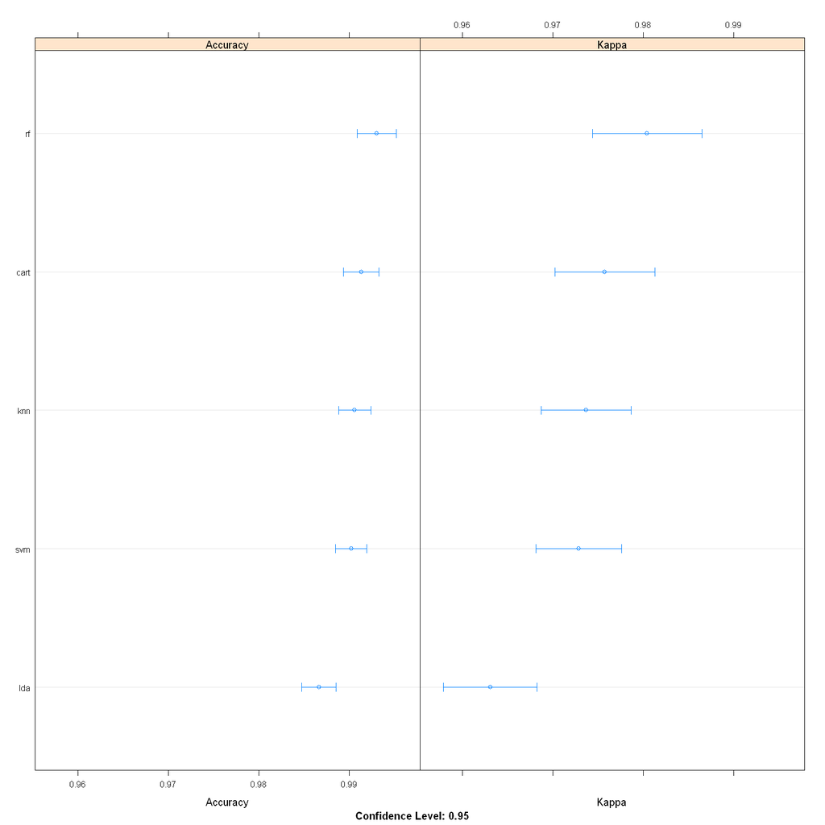

```r
dotplot(results)
```

```r
print(fit.lda)
```

```
Linear Discriminant Analysis

16448 samples
    5 predictor
    2 classes: 'no', 'yes'

No pre-processing
Resampling: Cross-Validated (10 fold)
Summary of sample sizes: 14803, 14803, 14803, 14803, 14803, 14803, ...
Resampling results:

  Accuracy   Kappa
  0.9866243  0.9630602
```

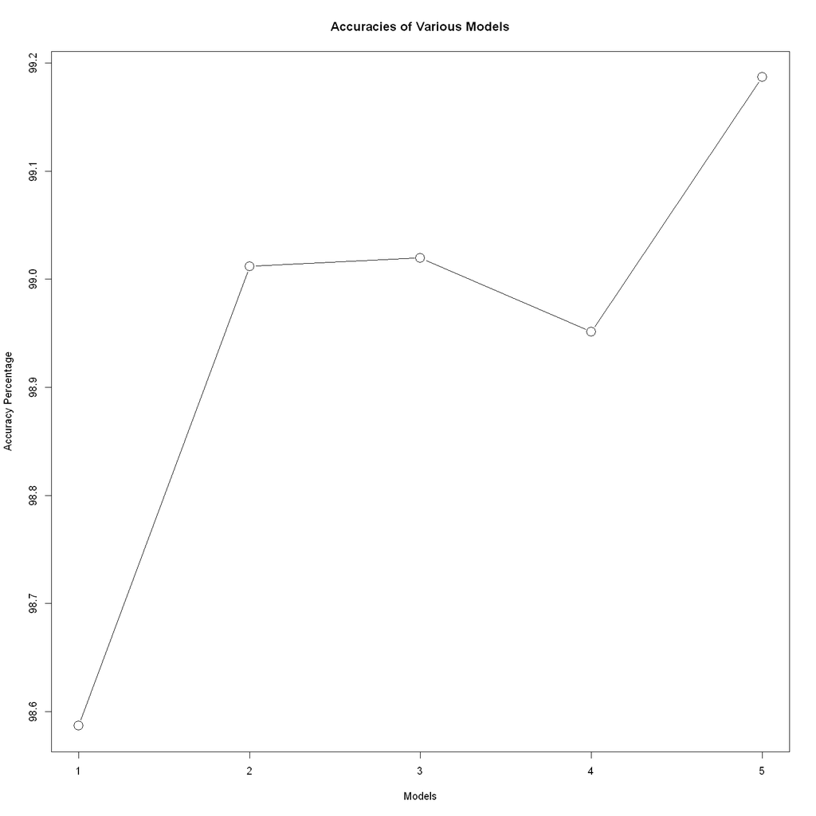

```r
plot(c(98.58649,99.01205,99.01966,98.95126,99.18686)
    ,main="Accuracies of Various Models",
    xlab="Models",ylab="Accuracy Percentage", type = "b",cex=2)
```

## 6. Make predictions

We see that the Random Forest was the most accurate of the all

```r
predictions <-predict(fit.rf,validation)
confusionMatrix(factor(as.character(predictions)),factor(validation$Occupancy))
```

```
Confusion Matrix and Statistics

          Reference
Prediction   no  yes
       no  3136   13
       yes   26  937

               Accuracy : 0.9905
                 95% CI : (0.9871, 0.9932)
    No Information Rate : 0.769
    P-Value [Acc > NIR] : < 2e-16

                  Kappa : 0.9734

 Mcnemar's Test P-Value : 0.05466

            Sensitivity : 0.9918
            Specificity : 0.9863
         Pos Pred Value : 0.9959
         Neg Pred Value : 0.9730
             Prevalence : 0.7690
         Detection Rate : 0.7626
   Detection Prevalence : 0.7658
      Balanced Accuracy : 0.9890

       'Positive' Class : no
```

Thus we see that the accuracy is pretty well in the accepable range and hence we will accept the model

# Conclusion

We tried to predict if the room was occupied or not and the results show we got accuracy of 99% which is great. We observed that Random forest worked the Best. During the process, we learnt A-Z about R i.e.

1. Installing the R platform.
2. Loading the dataset.
3. Summarizing the dataset.
4. Visualizing the dataset.
5. Evaluating some algorithms.
6. Making some predictions.